# Voter EDA

Keith G. Williams 800690755

Tuesday, April 19, 2016

This document is meant to be a mock-up of ideas for DSBA 5122 Visual Analytics Project.

Load the Voter Data from Mecklenburg County Board of Elections.

```r
library(readr)
setwd('~/DSBA 5122/Project')

voter <- read_csv('meck_voter.csv')
```

Clean

```r
library(stringr)

# Party Codes
voter$party_code <- str_replace_all(voter$party_code, '\r', '')
voter$party_code[voter$party_code == ""] <- NA

# District Descriptions
voter$ward_desc <- str_replace_all(voter$ward_desc,
                                   'CITY COUNCIL DISTRICT ',
                                   '')
voter$cong_dist_desc <- str_replace_all(voter$cong_dist_desc,
                                   'CONGRESSIONAL DISTRICT ',
                                   '')
voter$super_court_desc <- str_replace_all(voter$super_court_desc,
                                   'JUDICIAL DISTRICT ',
                                   '')
voter$nc_senate_desc <- str_replace_all(voter$nc_senate_desc,
                                   'NC SENATE DISTRICT ',
                                   '')
voter$nc_house_desc <- str_replace_all(voter$nc_house_desc,
                                   'NC HOUSE DISTRICT ',
                                   '')
voter$county_commiss_desc <- str_replace_all(voter$county_commiss_desc,
                                   'BOARD OF COMMISSIONERS DISTRICT ',
                                   '')
voter$school_dist_desc <- str_replace_all(voter$school_dist_desc,
                                   'SCHOOL BOARD DIST ',
                                   '')
voter$judic_dist_desc <- str_replace_all(voter$judic_dist_desc,
                                   'JUDICIAL DISTRICT ',
                                   '')
```

Visualize vote counts by election date

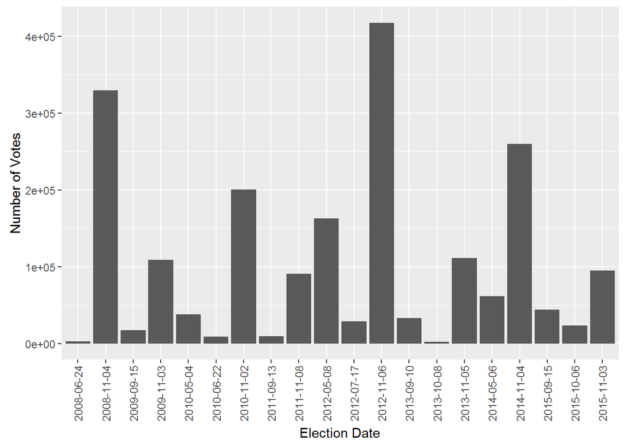

Examples of how this data can be “drilled-down”. Imagine a Check box on the left that allows the user to select which attributes the counts should be aggregated by. When clicking on “Party”, the previous graph turns into this graph.

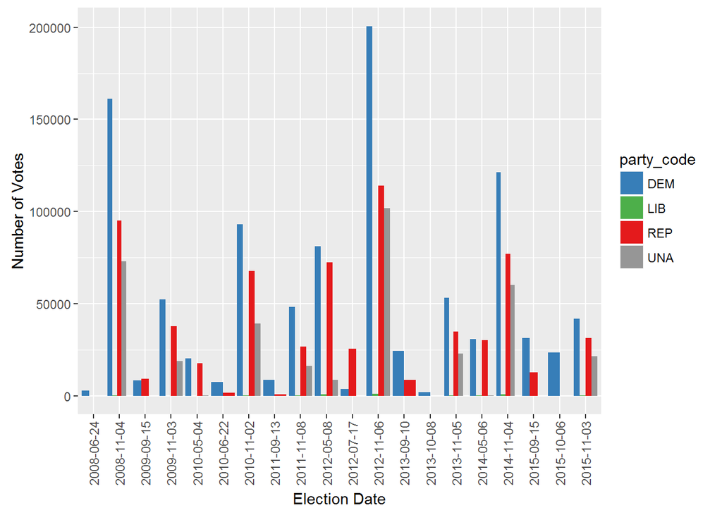

Since “LIB” appears so little, maybe the user can filter out these records:

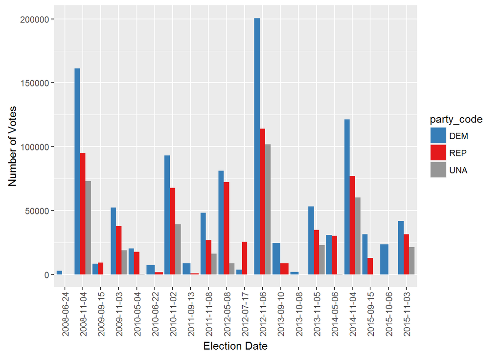

Example of making this interactive. Hover and Zoom features are nice here. Clicking on the legend is not that useful in this case.

[interactive chart not shown]

Other aggregations could be race, gender, age, congressional district (there are only 3 in Mecklenburg County), superior court district (again, only 3 in Mecklenburg County).

Next, a map like the one we can make in Tableau would be nice.

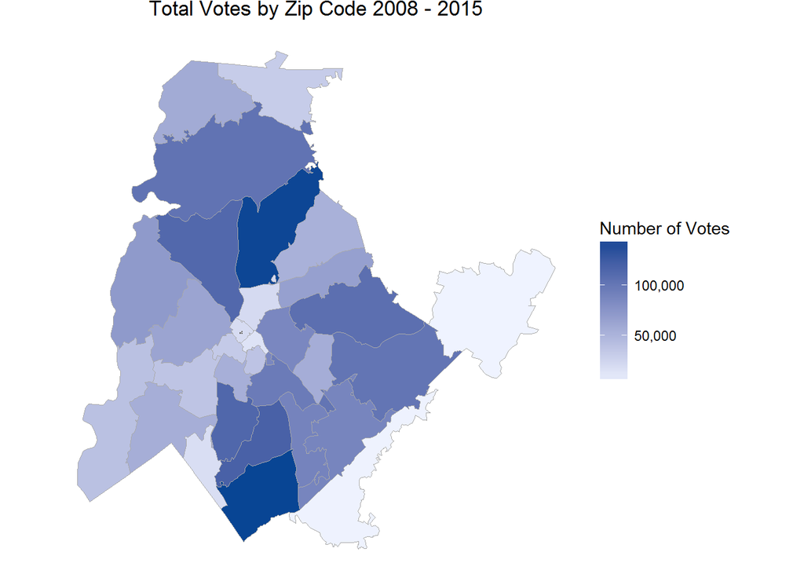

This map could come with an option to filter on election dates or by party or by demographics. Here’s an example with a reference map turned “ON”:

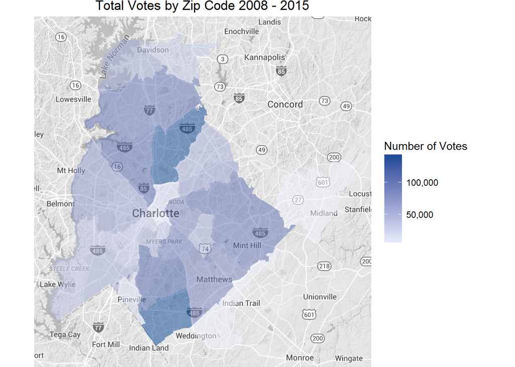